# Producing Parameterised Reports using {purrr} and {quarto}

Reprex of a workflow for producing parameterised reports using the {nycflights13} dataset

Author

Affiliation

Daniel Weiand

Newcastle upon Tyne Hospitals NHS Foundation Trust

Published

Thursday, 28 September, 2023

# Parameter(s) for report

This report focuses on the following parameter(s):

Destination airport: **NA**

Origin airport: **NA**

Month of flight: **NA**

# Aim

To run through a reproducible example (reprex) of a workflow for producing parameterised reports using {purrr}, {quarto} and the {nycflights13} dataset

# Why produce parameterised reports?

Creating parameterised reports (i.e., documents with outputs, incl. text, plots, tables, etc., that change based on the values of the parameters that you select) is a really common task for data analysts and data scientists, and it’s a task that can be made much easier with {quarto}.

# What is Quarto?

Quarto is a new open-source technical publishing system from RStudio/Posit:

- Similar in many ways to R Markdown
- Supports more languages (incl both R and Python)
- Combines the functionality of many R Markdown packages, e.g., {xaringan}, {bookdown}.
- Supports many different output formats (incl HTML, Word, PDF, revealjs, powerpoint, and so on)

# Background to the {nycflights13} package

nycflights13::flights contains 336776 detailed records of all flights that departed from NY in 2013.

```r
?flights # all flights that departed from NYC in 2013
?weather # hourly meterological data for each airport
?planes # construction information about each plane
?airports # airport names and locations
?airlines # translation between two letter carrier codes and names
```

# Related datasets of possible interest

If you’re interested in other subsets of flight data, related to the {nycflights13} dataset, see:

- [{nycflights}](https://github.com/jayleetx/nycflights) for flights departing from NYC in the last year.
- [{anyflights}](https://github.com/simonpcouch/anyflights) for flights departing from any airport in any year.
- [{airlines}](https://github.com/beanumber/airlines) to maintain a local SQL database of all flight departure data.

# Selection of parameter(s) for report

The nycflights13::flights dataset contains the following fields:

```r
year, month, day # Date of departure.

dep_time, arr_time # Actual departure and arrival times (format HHMM or HMM), local timezone (tz).

sched_dep_time, sched_arr_time # Scheduled departure and arrival times (format HHMM or HMM), local tz.

dep_delay, arr_delay # Departure and arrival delays, in minutes. Negative times represent early departures/arrivals.

carrier # Two letter carrier abbreviation. See airlines to get name.

flight # Flight number.

tailnum # Plane tail number. See ?planes for additional metadata.

origin, dest # Origin and destination. See airports for additional metadata.

air_time # Amount of time spent in the air, in minutes.

distance # Distance between airports, in miles.

hour, minute # Time of scheduled departure broken into hour and minutes.

time_hour # Scheduled date and hour of the flight as a POSIXct date. Along with origin, can be used to join flights data to weather data.
```

# Analysing your dataset for suitable parameters

For the purposes of this reprex, we can produce parameterised reports using subcategories of any variable/field included with the nycflights13::flights dataset.

```r
skimr::skim(nycflights13::flights) |>
  select(contains(c("skim", "complete", "missing", "unique", "hist"))) |>
  flextable::flextable() |>
  flextable::autofit() |>
  flextable::theme_vanilla()
```

| skim_type | skim_variable | complete_rate | n_missing | POSIXct.n_unique | character.n_unique | numeric.hist |
| --- | --- | --- | --- | --- | --- | --- |
| POSIXct | time_hour | 1.00 | 0 | 6,936 |  |  |
| character | carrier | 1.00 | 0 |  | 16 |  |
| character | tailnum | 0.99 | 2,512 |  | 4,043 |  |
| character | origin | 1.00 | 0 |  | 3 |  |
| character | dest | 1.00 | 0 |  | 105 |  |
| numeric | year | 1.00 | 0 |  |  | ▁▁▇▁▁ |
| numeric | month | 1.00 | 0 |  |  | ▇▆▆▆▇ |
| numeric | day | 1.00 | 0 |  |  | ▇▇▇▇▆ |
| numeric | dep_time | 0.98 | 8,255 |  |  | ▁▇▆▇▃ |
| numeric | sched_dep_time | 1.00 | 0 |  |  | ▁▇▇▇▃ |
| numeric | dep_delay | 0.98 | 8,255 |  |  | ▇▁▁▁▁ |
| numeric | arr_time | 0.97 | 8,713 |  |  | ▁▃▇▇▇ |
| numeric | sched_arr_time | 1.00 | 0 |  |  | ▁▃▇▇▇ |
| numeric | arr_delay | 0.97 | 9,430 |  |  | ▇▁▁▁▁ |
| numeric | flight | 1.00 | 0 |  |  | ▇▃▃▁▁ |
| numeric | air_time | 0.97 | 9,430 |  |  | ▇▂▂▁▁ |
| numeric | distance | 1.00 | 0 |  |  | ▇▃▂▁▁ |
| numeric | hour | 1.00 | 0 |  |  | ▁▇▇▇▅ |
| numeric | minute | 1.00 | 0 |  |  | ▇▃▆▃▅ |

# Requirements to produce parameterised reports

- A Quarto script, including parameter-specifying statements in YAML +/- body of report
- Wrangling of the dataset into “params”
- An R script to execute/render parameterised reports using Quarto

# Parameter-specifying statements

## In YAML

```r
# parameters for report, in YAML

params:
  dest: "NA"
  origin: "NA"
  month: "NA"
```

## In body of report

```r
# parameters for report, in body of text

This report focuses on the following parameter(s):

Destination airport: **`r params$dest`**

Origin airport: **`r params$origin`**

Month of flight departure: **`r params$month`**
```

# Wrangling of dataset into “params”

For each variable/field, put the following code in your Quarto script **after** loading required packages and datasets and **before** any further data wrangling steps:

```r
# e.g. params for nycflights13::flights$origin

if (!is.na(params$origin) && params$origin != "NA") {
  flights <- flights[flights$origin == params$origin, ]
}
if (nrow(flights) == 0) {
  stop("Invalid selection. Did you misspell `origin`?")
}
```

# Rendering parameterised reports using Quarto

There are three ways to render parameterised reports, in increasing order of complexity (and usefulness!)

## Rendering parameterised reports using YAML

1. Manually change the parameter values in the header YAML of your .qmd file and hit Render in RStudio. This is great for one-offs or for testing!

```r
# parameters for report

params:
  dest: "NA"
  origin: "JFK" # JFK airport specified
  month: "NA"
```

## Rendering parameterised reports using the terminal

2. Use the RStudio terminal to specify the parameter(s) you want to use.

```r
# Replacing XXXXX with one of the parameter's subcategories, e.g. for origin:"EWR", or "LGA", or "JFK"

# quarto render parameterised_quarto_report.qmd -P origin:XXXXX

# e.g. quarto render parameterised_quarto_report.qmd -P origin:JFK
```

## Rendering parameterised reports using the quarto::quarto_render() function

3. Leverage the quarto::quarto_render() function in R to automatically create a report for each parameter combination we want and name that file in a way that we specify.

This code must be saved in the form of a separate R script.

The {purrr} package helps to iteratively produce a report for every unique element of each specified parameter.

### One input

Use purrr:map() to iteratively produce a report for each element of one input.

```r
# for one input, create runparams function with one input: origin ------------------------

# create function to run a report against every subcategory of one variable, e.g. origin airport

runparams_one_input <- function(origin) {
  quarto::quarto_render(
    "parameterised_quarto_report.qmd",
    output_format = "html",
    execute_params = list(origin = origin),
    output_file = glue::glue("parameterised_quarto_report_{origin}.html")
  )
}

# to run a single report

runparams_one_input(origin = "JFK")

# execute with purrr:map() function

params_origin <- unique(flights$origin)

purrr::map(params_origin, runparams_one_input)
```

### Two inputs

Use purrr:map2() to iteratively produce a report for each element of two different inputs.

```r
# for two inputs, create runparams function with two inputs: origin and month -------------

# create function to run a report against every subcategory of two variables, e.g. both origin airport and month

runparams_two_inputs <- function(origin, month) {
  quarto::quarto_render(
    "parameterised_quarto_report.qmd",
    output_format = "html",
    execute_params = list(origin = origin, month = month),
    output_file = glue::glue("parameterised_quarto_report_{origin}_{month}.html")
  )
}

# execute with purrr:map2() function

x <- unique(flights$origin)
y <- unique(flights$month)
two_inputs <- tidyr::crossing(x, y)

purrr::map2(two_inputs$x, two_inputs$y,runparams_two_inputs)
```

# Analysis of {nycflights13} data

## Flight delay distribution

The figure below shows that the distribution of the delay in arrivals is right-skewed; it has a long tail.

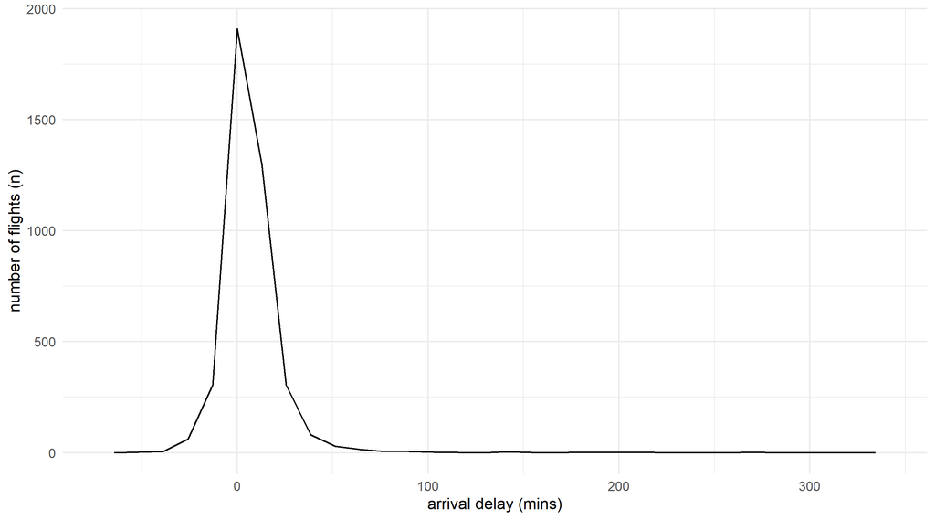

## Distance vs delay

From basic inspection we can find that there are 16 different carriers flying out of 3 NYC airports.

There are 105 different destination locations, serviced by 4044 unique planes.

8255 flight departures were cancelled.

## Plot of distance vs delay

Let’s examine the relationship between the distance and the average delay for each location. Lets explore the output visually

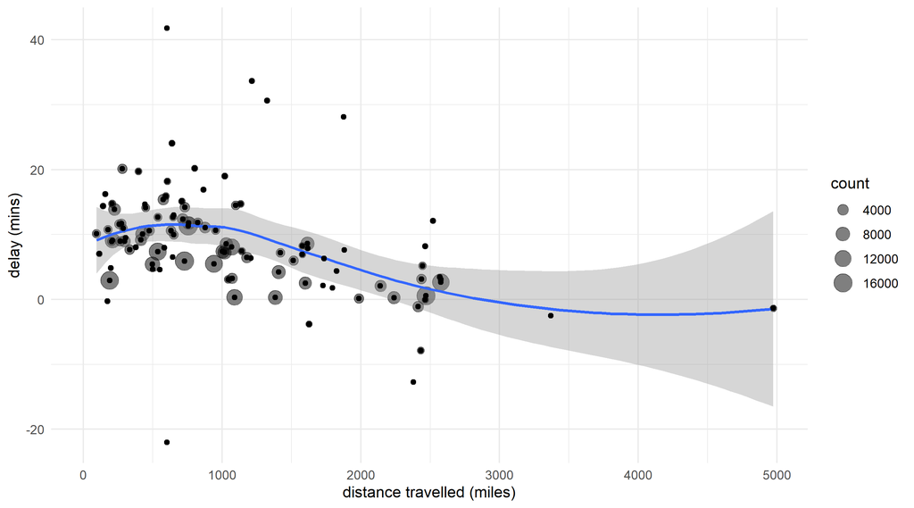

## Average delay (count)

The average delay was 7.09 minutes.

Lets explore even further, looking at the average delay for all planes planes that took more than 20 trips.

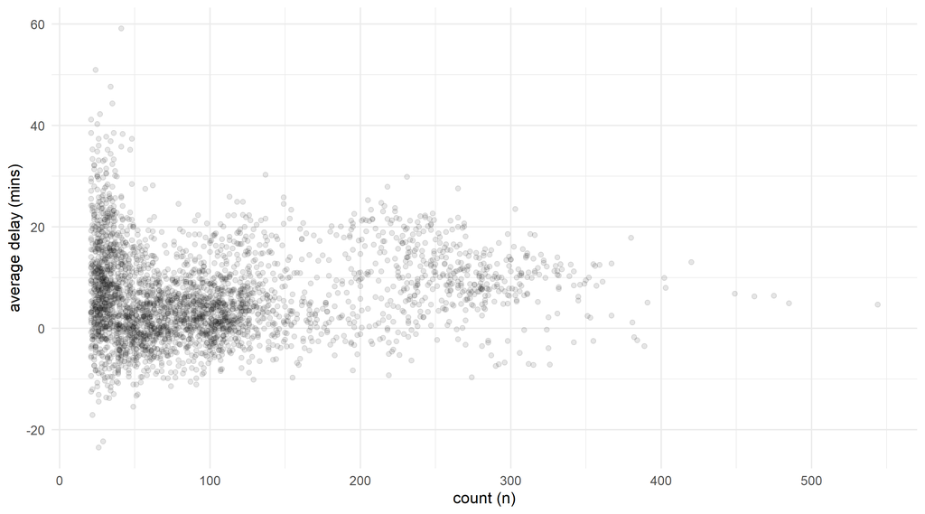

## Delay vs distance travelled

The following chart shows the departure delay, in minutes, for planes that took more than 20 trips, travelling between airports less than 3000 miles apart.

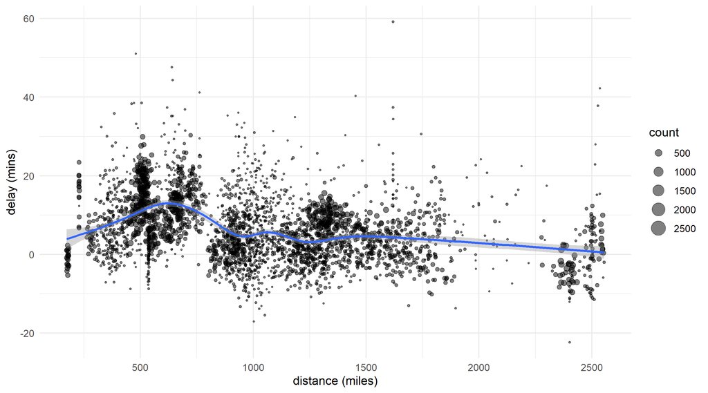

## Delay gain per hour

For planes that took more than 20 trips, where distance between airports was less than 3000 miles.

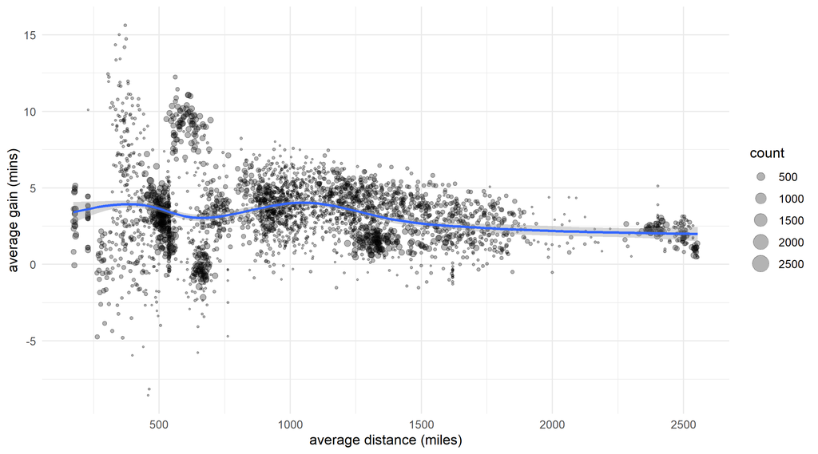

## Average departure delay (by origin airport)

Flights leaving from EWR had an average departure delay of 15.11 minutes.

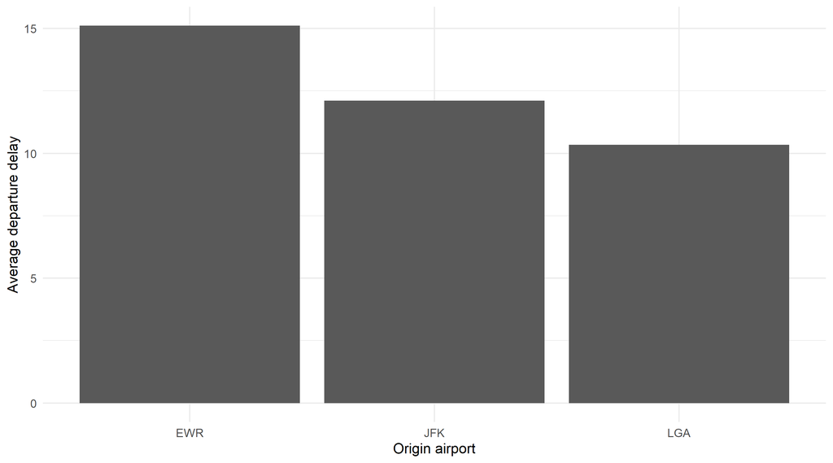

## Average departure delay (by destination airport)

Flights leaving to CAE had the longest average departure delay of 35.57 minutes.

The following plot shows the average departure delay (by destination airport), concentrating on destinations taking more than a 1000 flights in 2013 from EWR, LGA, JFK.

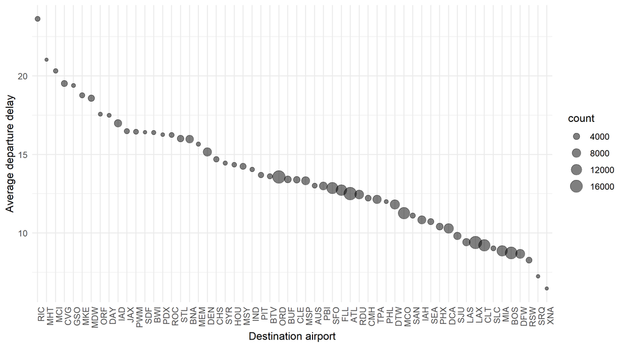

## Carrier vs air time

The following boxplot shows the mount of time spent in the air, in minutes, for each carrier departing from EWR, LGA, JFK.

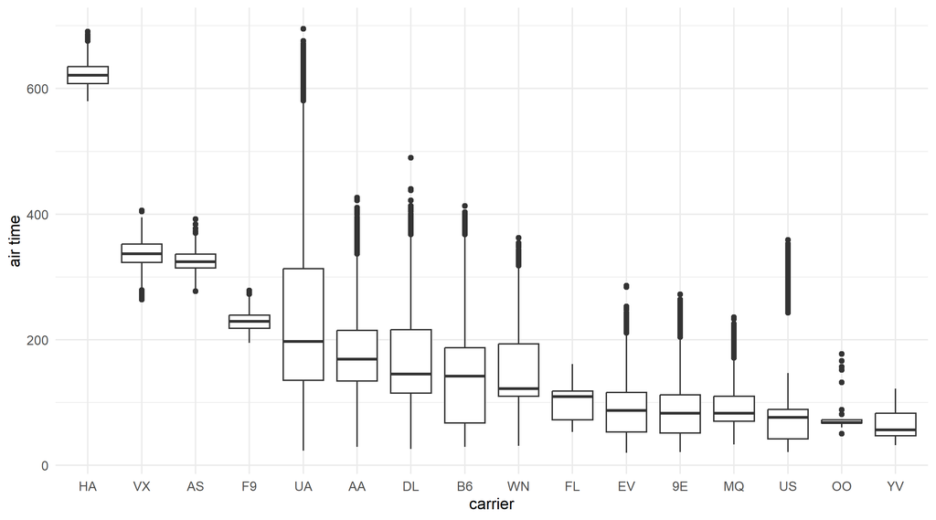

# Further reading and kudos

Jadey N Ryan gave an excellent talk on creating parameterised reports at this year’s posit::conf(2023)

[tinyurl.com/quarto-params](https://jadeynryan.github.io/2023_posit-parameterized-quarto/)

github.com/jadeynryan

Megan Hall wrote an excellent blog post on creating parameterised reports

https://meghan.rbind.io/blog/quarto-pdfs

https://github.com/meghall06

I’ve created a reprex of a workflow for producing parameterised reports using the {nycflights13} dataset. This was delivered as an online workshop @ NHS-R and NHS.pycom conf (2023) | September 29

[https://nhsrcommunity.com/events](https://nhsrcommunity.com/events/nhs-r-nhs-pycom-online-conference-workshop-2023-producing-parameterised-reports-using-purrr-and-quarto/)

github.com/send2dan/public

# Summary

R benefits from a worldwide community that **freely** shares learning and resources, through e.g. [GitHub](https://github.com/send2dan/)

I hope you enjoyed reading through this reprex of a workflow for producing parameterised reports using {purrr}, {quarto} and the {nycflights13} dataset.

Creating parameterised documents is much easier with {quarto}, which supports languages incl both R and Python to produce reports in many different different output formats.

Using the {nycflights13} dataset, which is freely available to everyone, should help any interested parties to run the necessary code from their own computers.

The skimr::skim() function helps identify variables that may be of interest when producing parameterised reports.

The only prerequisites for producing parameterised reports are: - A Quarto script, including a YAML parameter statement - Wrangling of the dataset into “params” - An R script to execute/render parameterised reports using Quarto

The {purrr} package helps to iteratively produce a report for every unique combination of specified parameters.

There are three ways to render parameterised reports, in increasing order of complexity, the third of which is by far the most useful, in that it automatically creates and names reports for each parameter combination of interest.

For copies of the code, check out my [GitHub](https://github.com/send2dan/) page.